# Data Structures

# Vectors

```r
(grand_slam_win <- c(9, 15, 5, 12, 18))
```

```
## [1]  9 15  5 12 18
```

```r
a = c(1,2,3)
b = c(4,5,6)
(d = c(a,b,a))
```

```
## [1] 1 2 3 4 5 6 1 2 3
```

```r
(d1 = c("a", "b", "a"))
```

```
## [1] "a" "b" "a"
```

##### On Types

Types can be double = real number or character (and others)

```r
typeof(d)
```

```
## [1] "double"
```

```r
typeof(d1)
```

```
## [1] "character"
```

```r
typeof(grand_slam_win)
```

```
## [1] "double"
```

When creating a vector with different types of element there an order to transform some of them in order to make them all the same (see book sec 4.1.2 coercion)

```r
(d2 = c(a, d1))
```

```
## [1] "1" "2" "3" "a" "b" "a"
```

```r
typeof(d2)
```

```
## [1] "character"
```

##### Subsetting (subset of vectors)

```r
(a = c(321, 14, 1134, 465, 643, 6343, 64))
```

```
## [1]  321   14 1134  465  643 6343   64
```

```r
a[3]
```

```
## [1] 1134
```

```r
a[c(5, 1, 3)]
```

```
## [1]  643  321 1134
```

```r
a[-3]
```

```
## [1]  321   14  465  643 6343   64
```

```r
a[-c(1, 2)]
```

```
## [1] 1134  465  643 6343   64
```

We cannot do this a[c(1, 2, -3)], but we can do

```r
a[c(1, 2, 4)] [-3]
```

```
## [1] 321  14
```

```r
a[c(1, 2, 4)] [-4]
```

```
## [1] 321  14 465
```

Another way of subsetting

```r
a[c(F, T, F, T, F, F, F)]
```

```
## [1]  14 465
```

```r
a[a > 600]
```

```
## [1] 1134  643 6343
```

```r
a > 600
```

```
## [1] FALSE FALSE  TRUE FALSE  TRUE  TRUE FALSE
```

##### Attributes

```r
(grand_slam_win <- c("Andy Murray" = 9, "Rafael Nadal" = 15,
                   "Stan Wawrinka" = 5, "Novak Djokovic" = 12,
                   "Roger Federer" = 18))
```

```
##    Andy Murray   Rafael Nadal  Stan Wawrinka Novak Djokovic  Roger Federer
##              9             15              5             12             18
```

Same commande

```r
grand_slam_win[4]
```

```
## Novak Djokovic
##             12
```

```r
grand_slam_win["Novak Djokovic"]
```

```
## Novak Djokovic
##             12
```

```r
length(grand_slam_win)
```

```
## [1] 5
```

```r
sort(grand_slam_win)
```

```
##  Stan Wawrinka    Andy Murray Novak Djokovic   Rafael Nadal  Roger Federer
##              5              9             12             15             18
```

```r
order(grand_slam_win)
```

```
## [1] 3 1 4 2 5
```

Sort can be done like that :)

```r
grand_slam_win[order(grand_slam_win)]
```

```
##  Stan Wawrinka    Andy Murray Novak Djokovic   Rafael Nadal  Roger Federer
##              5              9             12             15             18
```

##### Sequences

The last one is taking equidistant value between 3 and 7.4

```r
1:6
```

```
## [1] 1 2 3 4 5 6
```

```r
6:1
```

```
## [1] 6 5 4 3 2 1
```

```r
seq(from = 3, to = 7.4, length.out = 10)
```

```
##  [1] 3.000000 3.488889 3.977778 4.466667 4.955556 5.444444 5.933333
##  [8] 6.422222 6.911111 7.400000
```

Say you want to have the date of three months ago

1. create the vector today

```r
(today = Sys.Date())
```

```
## [1] "2019-07-02"
```

2. extract the date of three months ago

```r
(three_months_ago = seq(today, length = 2, by = "-3 months" )[2])
```

```
## [1] "2019-04-02"
```

##### Exemple

```r
library(quantmod)
getSymbols("AAPL", from = three_months_ago, to = today)
```

[output not shown]

```
## [1] "AAPL"
```

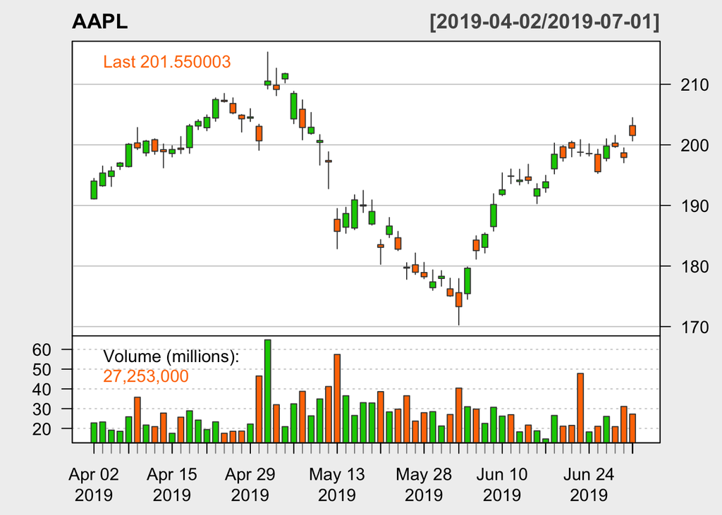

```r
candleChart(AAPL, theme = 'white', type = 'candles')
```

```r
AAPL
```

```
##            AAPL.Open AAPL.High AAPL.Low AAPL.Close AAPL.Volume
## 2019-04-02    191.09    194.46   191.05     194.02    22765700
## 2019-04-03    193.25    196.50   193.15     195.35    23271800
## 2019-04-04    194.79    196.37   193.14     195.69    19114300
## 2019-04-05    196.45    197.10   195.93     197.00    18526600
## 2019-04-08    196.42    200.23   196.34     200.10    25881700
## 2019-04-09    200.32    202.85   199.23     199.50    35768200
## 2019-04-10    198.68    200.74   198.18     200.62    21695300
## 2019-04-11    200.85    201.00   198.44     198.95    20900800
## 2019-04-12    199.20    200.14   196.21     198.87    27760700
## 2019-04-15    198.58    199.85   198.01     199.23    17536600
## 2019-04-16    199.46    201.37   198.56     199.25    25696400
## 2019-04-17    199.54    203.38   198.61     203.13    28906800
## 2019-04-18    203.12    204.15   202.52     203.86    24195800
## 2019-04-22    202.83    204.94   202.34     204.53    19439500
## 2019-04-23    204.43    207.75   203.90     207.48    23323000
## 2019-04-24    207.36    208.48   207.05     207.16    17540600
## 2019-04-25    206.83    207.76   205.12     205.28    18543200
## 2019-04-26    204.90    205.00   202.12     204.30    18649100
## 2019-04-29    204.40    205.97   203.86     204.61    22204700
## 2019-04-30    203.06    203.40   199.11     200.67    46534900
## 2019-05-01    209.88    215.31   209.23     210.52    64827300
## 2019-05-02    209.84    212.65   208.13     209.15    31996300
## 2019-05-03    210.89    211.84   210.23     211.75    20892400
## 2019-05-06    204.29    208.84   203.50     208.48    32443100
## 2019-05-07    205.88    207.42   200.83     202.86    38763700
## 2019-05-08    201.90    205.34   201.75     202.90    26339500
## 2019-05-09    200.40    201.68   196.66     200.72    34908600
## 2019-05-10    197.42    198.85   192.77     197.18    41208700
## 2019-05-13    187.71    189.48   182.85     185.72    57430600
## 2019-05-14    186.41    189.70   185.41     188.66    36529700
## 2019-05-15    186.27    191.75   186.02     190.92    26544700
## 2019-05-16    189.91    192.47   188.84     190.08    33031400
## 2019-05-17    186.93    190.90   186.76     189.00    32879100
## 2019-05-20    183.52    184.35   180.28     183.09    38612300
## 2019-05-21    185.22    188.00   184.70     186.60    28364800
## 2019-05-22    184.66    185.71   182.55     182.78    29748600
## 2019-05-23    179.80    180.54   177.81     179.66    36529700
## 2019-05-24    180.20    182.14   178.62     178.97    23714700
## 2019-05-28    178.92    180.59   177.91     178.23    27948200
```

[output cut: 73 more lines]

```
## 2019-06-11      194.8100
## 2019-06-12      194.1900
## 2019-06-13      194.1500
## 2019-06-14      192.7400
## 2019-06-17      193.8900
## 2019-06-18      198.4500
## 2019-06-19      197.8700
## 2019-06-20      199.4600
## 2019-06-21      198.7800
## 2019-06-24      198.5800
## 2019-06-25      195.5700
## 2019-06-26      199.8000
## 2019-06-27      199.7400
## 2019-06-28      197.9200
## 2019-07-01      201.5500
```

```r
ClCl(AAPL)
```

```
##                ClCl.AAPL
## 2019-04-02            NA
## 2019-04-03  0.0068549736
## 2019-04-04  0.0017404453
## 2019-04-05  0.0066942510
## 2019-04-08  0.0157360711
## 2019-04-09 -0.0029985306
## 2019-04-10  0.0056140100
## 2019-04-11 -0.0083241852
## 2019-04-12 -0.0004021211
## 2019-04-15  0.0018102329
## 2019-04-16  0.0001004066
## 2019-04-17  0.0194730489
## 2019-04-18  0.0035937379
## 2019-04-22  0.0032865594
## 2019-04-23  0.0144232974
## 2019-04-24 -0.0015422788
## 2019-04-25 -0.0090751350
## 2019-04-26 -0.0047739478
## 2019-04-29  0.0015173666
## 2019-04-30 -0.0192561604
## 2019-05-01  0.0490855938
## 2019-05-02 -0.0065077426
## 2019-05-03  0.0124312985
## 2019-05-06 -0.0154427580
## 2019-05-07 -0.0269569988
## 2019-05-08  0.0001971458
## 2019-05-09 -0.0107441748
## 2019-05-10 -0.0176365483
## 2019-05-13 -0.0581194462
## 2019-05-14  0.0158302982
## 2019-05-15  0.0119791898
## 2019-05-16 -0.0043997277
## 2019-05-17 -0.0056818286
## 2019-05-20 -0.0312698624
## 2019-05-21  0.0191709546
## 2019-05-22 -0.0204716339
## 2019-05-23 -0.0170696740
## 2019-05-24 -0.0038406044
## 2019-05-28 -0.0041347991
```

[output cut: 9 more lines]

```
## 2019-06-11  0.0115795824
## 2019-06-12 -0.0031825677
## 2019-06-13 -0.0002060250
## 2019-06-14 -0.0072623695
## 2019-06-17  0.0059665558
## 2019-06-18  0.0235184797
## 2019-06-19 -0.0029226607
## 2019-06-20  0.0080356398
## 2019-06-21 -0.0034092448
## 2019-06-24 -0.0010061224
## 2019-06-25 -0.0151575938
## 2019-06-26  0.0216290630
## 2019-06-27 -0.0003002903
## 2019-06-28 -0.0091118802
## 2019-07-01  0.0183407692
```

```r
mean(ClCl(AAPL))
```

```
## [1] NA
```

```r
mean(na.omit(ClCl(AAPL)))
```

```
## [1] 0.000748375
```

##### Matrices

We can create matrices with vectors

```r
players <- c("Andy Murray", "Rafael Nadal", "Stan Wawrinka",
             "Novak Djokovic", "Roger Federer")
grand_slam_win <- c(9, 15, 5, 12, 18)
win_percentage <- c(78.07, 82.48, 63.96, 82.77, 81.80)
(mat <- cbind(grand_slam_win, win_percentage))
```

```
##      grand_slam_win win_percentage
## [1,]              9          78.07
## [2,]             15          82.48
## [3,]              5          63.96
## [4,]             12          82.77
## [5,]             18          81.80
```

We can give other names to column or rows

```r
rownames(mat) <- players
colnames(mat) <- c("GS win", "Win rate")
mat
```

```
##                GS win Win rate
## Andy Murray         9    78.07
## Rafael Nadal       15    82.48
## Stan Wawrinka       5    63.96
## Novak Djokovic     12    82.77
## Roger Federer      18    81.80
```

Here’s another way (the [[2]] correspond to the column, [[1]] would be the row)

```r
dimnames(mat)[[2]] <- c("GS wins", "Win rate")
mat
```

```
##                GS wins Win rate
## Andy Murray          9    78.07
## Rafael Nadal        15    82.48
## Stan Wawrinka        5    63.96
## Novak Djokovic      12    82.77
## Roger Federer       18    81.80
```

Matrice transpose and matrice product

```r
t(mat)
```

```
##          Andy Murray Rafael Nadal Stan Wawrinka Novak Djokovic
## GS wins         9.00        15.00          5.00          12.00
## Win rate       78.07        82.48         63.96          82.77
##          Roger Federer
## GS wins           18.0
## Win rate          81.8
```

```r
mat%*%t(mat)
```

```
##                Andy Murray Rafael Nadal Stan Wawrinka Novak Djokovic
## Andy Murray       6175.925     6574.214      5038.357       6569.854
## Rafael Nadal      6574.214     7027.950      5350.421       7006.870
## Stan Wawrinka     5038.357     5350.421      4115.882       5353.969
## Novak Djokovic    6569.854     7006.870      5353.969       6994.873
## Roger Federer     6548.126     7016.864      5321.928       6986.586
##                Roger Federer
## Andy Murray         6548.126
## Rafael Nadal        7016.864
## Stan Wawrinka       5321.928
## Novak Djokovic      6986.586
## Roger Federer       7015.240
```

##### Exemple

```r
# Load quantmod
library(quantmod)

# Download data
today <- Sys.Date()
five_years_ago <- seq(today, length = 2, by = "-5 year")[2]
getSymbols("AAPL", from = five_years_ago, to = today)
```

```
## [1] "AAPL"
```

```r
getSymbols("NFLX", from = five_years_ago, to = today)
```

```
## [1] "NFLX"
```

```r
# Compute returns
Ra <- na.omit(ClCl(AAPL))
Rn <- na.omit(ClCl(NFLX))

# Estimation of mu and Sigma
Sigma <- cov(cbind(Ra, Rn))
mu <- c(mean(Ra), mean(Rn))
Sigma
```

```
##              ClCl.AAPL    ClCl.NFLX
## ClCl.AAPL 0.0002410186 0.0001522054
## ClCl.NFLX 0.0001522054 0.0007035009
```

```r
mu
```

```
## [1] 0.000732063 0.001722800
```

```r
# Compute omega^*
omega_star <- (Sigma[2, 2] - Sigma[1, 2])/(Sigma[1, 1] + Sigma[2, 2] - 2*Sigma[1, 2])
omega_star
```

```
## [1] 0.861253
```

```r
# Compute investment expected value and variance
mu_investment <- omega_star*mu[1] + (1 - omega_star)*mu[2]
var_investment <- omega_star^2*Sigma[1,1] + (1 - omega_star)^2*Sigma[2,2] +
  2*omega_star*(1 - omega_star)*Sigma[1,2]


investment_summary <- matrix(NA, 2, 3)
dimnames(investment_summary)[[1]] <- c("Expected value", "Variance")
dimnames(investment_summary)[[2]] <- c("Apple", "Netflix", "Investment")
investment_summary[1, ] <- c(mu, mu_investment)
investment_summary[2, ] <- c(diag(Sigma), var_investment)
knitr::kable(investment_summary)
```

|  | Apple | Netflix | Investment |
| --- | --- | --- | --- |
| Expected value | 0.0007321 | 0.0017228 | 0.0008695 |
| Variance | 0.0002410 | 0.0007035 | 0.0002287 |

##### List

A list is a heterogenious object

```r
# List elements
num_vec <- c(188, 140)
char_vec <- c("Height", "Weight", "Length")
logic_vec <- rep(TRUE, 8)
my_mat <- matrix(0, nrow = 5, ncol = 5)

# List initialization
(my_list <- list(num_vec, char_vec, logic_vec, my_mat))
```

```
## [[1]]
## [1] 188 140
##
## [[2]]
## [1] "Height" "Weight" "Length"
##
## [[3]]
## [1] TRUE TRUE TRUE TRUE TRUE TRUE TRUE TRUE
##
## [[4]]
##      [,1] [,2] [,3] [,4] [,5]
## [1,]    0    0    0    0    0
## [2,]    0    0    0    0    0
## [3,]    0    0    0    0    0
## [4,]    0    0    0    0    0
## [5,]    0    0    0    0    0
```

Subsetting list

1. give name to the elements of the list

```r
(my_list <- list(number = num_vec, character = char_vec,
                 logic = logic_vec, matrix = my_mat))
```

```
## $number
## [1] 188 140
##
## $character
## [1] "Height" "Weight" "Length"
##
## $logic
## [1] TRUE TRUE TRUE TRUE TRUE TRUE TRUE TRUE
##
## $matrix
##      [,1] [,2] [,3] [,4] [,5]
## [1,]    0    0    0    0    0
## [2,]    0    0    0    0    0
## [3,]    0    0    0    0    0
## [4,]    0    0    0    0    0
## [5,]    0    0    0    0    0
```

2. subsetting (two ways)

```r
my_list$character
```

```
## [1] "Height" "Weight" "Length"
```

```r
my_list[[2]]
```

```
## [1] "Height" "Weight" "Length"
```

The good thing with List is that the elements don’t need to be of the same length.

##### Data Frames

If one the contrary the elements of a list have the same length, the we can use a data frame instead

```r
### Creation

players <- c("Andy Murray", "Rafael Nadal", "Stan Wawrinka",
             "Novak Djokovic", "Roger Federer")

grand_slam_win <- c(9, 15, 5, 12, 18)

date_of_birth <- c("15 May 1987", "3 June 1986", "28 March 1985",
                  "22 May 1987", "8 August 1981")

country <- c("Great Britain", "Spain", "Switzerland",
            "Serbia", "Switzerland")
ATP_ranking <- c(1, 2, 3, 4, 5)

prize_money <- c(60449649, 85920132, 30577981, 109447408, 104445185)

tennis <- data.frame(date_of_birth, grand_slam_win, country,
                    ATP_ranking, prize_money)
tennis
```

```
##   date_of_birth grand_slam_win       country ATP_ranking prize_money
## 1   15 May 1987              9 Great Britain           1    60449649
## 2   3 June 1986             15         Spain           2    85920132
## 3 28 March 1985              5   Switzerland           3    30577981
## 4   22 May 1987             12        Serbia           4   109447408
## 5 8 August 1981             18   Switzerland           5   104445185
```

If we want to give names to the rows, we do

```r
# Attenttion: dimnames(tennis) is a list, whereas tennis is a data frame
dimnames(tennis)[[1]] <- players
tennis
```

```
##                date_of_birth grand_slam_win       country ATP_ranking
## Andy Murray      15 May 1987              9 Great Britain           1
## Rafael Nadal     3 June 1986             15         Spain           2
## Stan Wawrinka  28 March 1985              5   Switzerland           3
## Novak Djokovic   22 May 1987             12        Serbia           4
## Roger Federer  8 August 1981             18   Switzerland           5
##                prize_money
## Andy Murray       60449649
## Rafael Nadal      85920132
## Stan Wawrinka     30577981
## Novak Djokovic   109447408
## Roger Federer    104445185
```

Check the type

```r
is.list(2)
```

```
## [1] FALSE
```

```r
is.list(tennis)
```

```
## [1] TRUE
```

```r
is.data.frame(tennis)
```

```
## [1] TRUE
```

##### Graphs

```r
# load the x-value and y-value.
# We can use the following table investement_summary
# etc...
```

##### Code

We start with logical operator between number of 1-dim object

```r
a = 3
b = 4
a < b
```

```
## [1] TRUE
```

```r
!(a > b) || b < 0
```

```
## [1] TRUE
```

```r
!(a > b) && b < 0
```

```
## [1] FALSE
```

If we have vectors

```r
a = 1:12
a > 10
```

```
##  [1] FALSE FALSE FALSE FALSE FALSE FALSE FALSE FALSE FALSE FALSE  TRUE
## [12]  TRUE
```

it can be problematic cause here only the first value of the vecor is checked.

```r
a > 5 && a < 10
```

```
## [1] FALSE
```

To do it with vectors we use & instead of &&

```r
a > 5 & a < 10
```

```
##  [1] FALSE FALSE FALSE FALSE FALSE  TRUE  TRUE  TRUE  TRUE FALSE FALSE
## [12] FALSE
```

```r
a[a > 5 & a < 10]
```

```
## [1] 6 7 8 9
```

```r
sum(a > 5 & a < 10)
```

```
## [1] 4
```

Code if a number is even or odd

```r
a = 4
if(a %% 2 == 0){
  print("even")
}else{
  print("odd")
}
```

```
## [1] "even"
```

Or we can do and use the paste function since a and “even” are not of the same type

```r
a = 4
if(a %% 2 == 0){
  print(paste(a,"is even"))
}else{
  print(paste(a,"is odd"))
}
```

```
## [1] "4 is even"
```

Using for and if

```r
a = 2
for(i in 1:6){
  if(a > 5){
    a = 2
  }
  a = a+1
}
a
```

```
## [1] 4
```

We are going to make the sum of the elements of a vector in two ways

1. simple

```r
a = 1:6
sum(a)
```

```
## [1] 21
```

2. tricky

```r
a = 1:6
mysum = 0
for(i in 1:length(a)){
  mysum = mysum + a[i]
}
mysum
```

```
## [1] 21
```